# Анализ панельных данных. Знакомство с моделями с фиксированными эффектами

### Дата занятия: 12 сентября

## Будем знать панельные данные “в лицо”

Для начала посмотрим на то, как панельные данные могут быть представлены в массиве. Возьмем “кусочек” данных (*включает только часть стран исходного массива*), с которыми будем работать далее на практическом занятии. Источник данных – проект Всемирного банка Worldwide Governance Indicators. В текущем массиве представлены данные по политической стабильности и контролю коррупции за 2006 – 2015 гг. для Австралии, Великобритании, Канады, Новой Зеландии и США.

**pol_stab** – Политическая стабильность и отсутствие насилия/терроризма. Отражает склонность к политической нестабильности и/или политически мотивированному насилию, включая терроризм. Значения показателя варьируются от −2.5 до 2.5, причем более высокие значения означают более высокий уровень политической стабильности.

**con_cor** – Показатель контроля коррупции. Отражает восприятие степени использования государственной власти для личной выгоды, включая как мелкие, так и крупные формы коррупции. Показатель изменяется от −2.5 до 2.5, причем более высокие значения соответствуют более низкому уровню коррупции (т.е. более высокому контролю).

Посмотрим, как представлены данные для первой страны в массиве – Австралии. В качестве наблюдения теперь можно рассматривать не пространственную единицу, а комбинацию: “страна – год”:

```r
dta1 <- readRDS("RAPDC_lecture1_example1.rds")

head(dta1, 10)
```

| year | country | pol_stab | con_cor |
| --- | --- | --- | --- |
| 2006 | Australia | 0.9351878 | 1.960568 |
| 2007 | Australia | 0.9287898 | 2.010918 |
| 2008 | Australia | 0.9556448 | 2.042482 |
| 2009 | Australia | 0.8556890 | 2.051661 |
| 2010 | Australia | 0.8888599 | 2.031455 |
| 2011 | Australia | 0.9357101 | 2.044637 |
| 2012 | Australia | 0.9979972 | 1.985774 |
| 2013 | Australia | 1.0310730 | 1.785322 |
| 2014 | Australia | 1.0321920 | 1.853449 |
| 2015 | Australia | 0.8849798 | 1.882090 |

Точно таким же образом организованы данные и для других стран. Так для США – последней страны в массиве – видим аналогичную структуру:

```r
tail(dta1, 10)
```

| year | country | pol_stab | con_cor |
| --- | --- | --- | --- |
| 2006 | USA | 0.4939433 | 1.353316 |
| 2007 | USA | 0.3757299 | 1.385467 |
| 2008 | USA | 0.5852239 | 1.450212 |
| 2009 | USA | 0.4484303 | 1.294352 |
| 2010 | USA | 0.4384039 | 1.271479 |
| 2011 | USA | 0.5912473 | 1.269101 |
| 2012 | USA | 0.6324421 | 1.410720 |
| 2013 | USA | 0.6430726 | 1.313262 |
| 2014 | USA | 0.5824196 | 1.376068 |
| 2015 | USA | 0.6780624 | 1.396919 |

В общем виде можно использовать следующее обозначение: $x_{it}$, где $x$ – сам показатель, $i$ – субиндекс, отвечающий за пространственную единицу, $t$ – субиндекс, отвечающий за временной период. Далее будем также обозначать как N - общее количество пространственных единиц, а T – общее количество временных периодов.

## А что если, как уже умеем, применить pooled model?

Такие данные отличаются от тех данных, которые мы рассматривали в прошлом году, тем, что наблюдения в данном случае не являются независимыми. Условно массив можно разделить на N подгрупп – N стран. Внутри каждой такой подгруппы данные связаны: наблюдается зависимость между значениями показателей в разные временные периоды. Кстати, аналогично мы могли бы разделить массив на T подгрупп, выделенных на основе количества временных периодов, и посмотреть, а как же связаны данные по странам, собранные за один и тот же год.

Посмотрим, можно ли применить классическую линейную регрессионную модель без всяких поправок (pooled model – то есть, будем рассматривать массив как единый, закрывая глаза на то, что есть и пространственная, и временная перспектива) – ту модель, которую мы рассматривали в прошлом году – для анализа таких данных. Применить-то можем, но то, что получится, нас не порадует. В результате такого подхода “в лоб” получим вот такие результаты, картинку ниже можно было бы считать, как то, что с ростом контроля коррупции увеличивается и показатель политической стабильности.

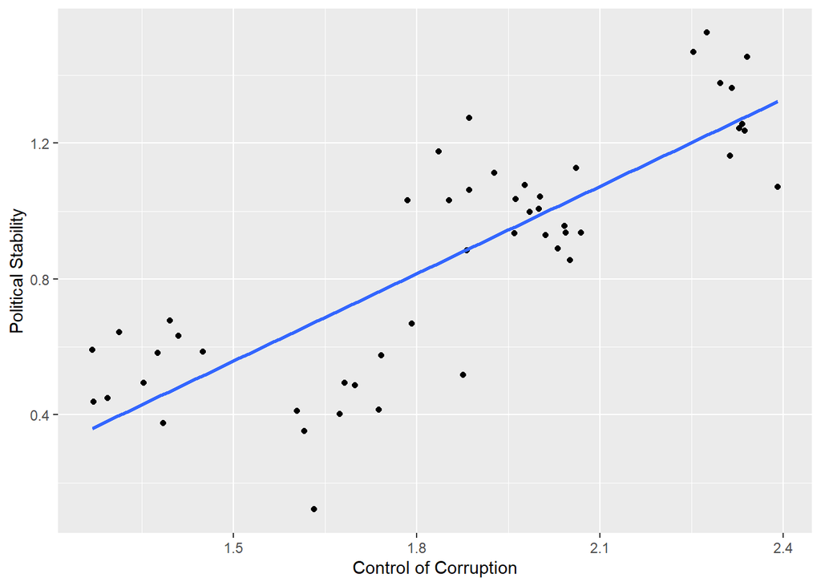

```r
ggplot(dta1, aes(x = con_cor, y = pol_stab)) +
  geom_point() +
  geom_smooth(method = lm, se = F) +
  xlab("Control of Corruption") +
  ylab("Political Stability")
```

Однако если учесть разные подгруппы наблюдений, выделенные по пространственным единицам (разным цветом на графике обозначим разные страны), то увидим, что не все так однозначно. Картинка же выше “съела” имеющиеся различия.

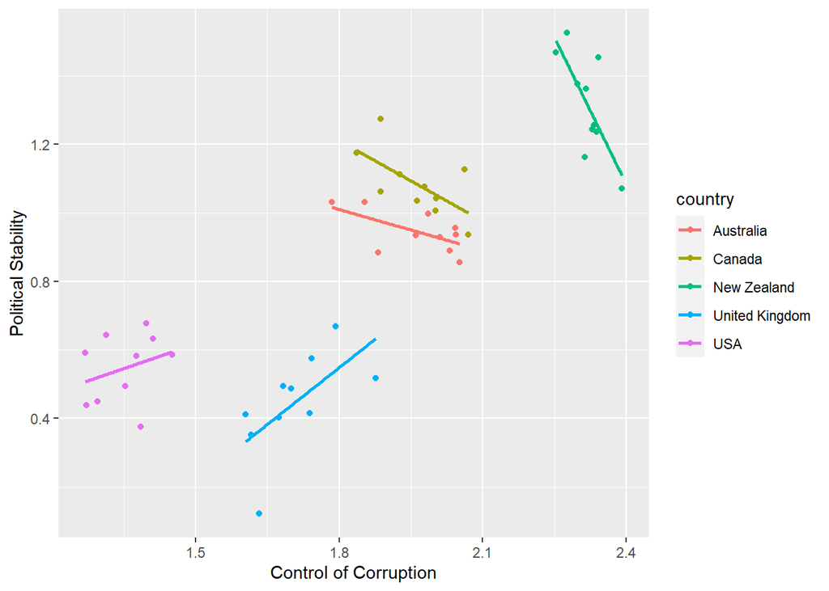

```r
ggplot(dta1, aes(x = con_cor, y = pol_stab, color = country)) +
  geom_point() +
  geom_smooth(method = lm, se = F) +
  xlab("Control of Corruption") +
  ylab("Political Stability")
```

Таким образом, можно отметить, что необдуманное применение pooled model может привести к смещению в результатах. Кроме того, возникнут проблемы со значимостью результатов. Так как массив воспринимается как единый, без разграничения на подгруппы, N велико, а значит стандартные ошибки малы, и вследствие этого мы будем с большей вероятностью интерпретировать результаты как значимые, когда это не так.

## Что же делать?

В качестве одной из возможных альтернатив для анализа панельных данных выступает модель с фиксированными эффектами (FE-model). Мы исходим из простой предпосылки о том, что стартовые условия разные, а взаимосвязь рассматриваемых показателей одинакова во всех странах.

### 1. Далекая от элегантной LSDV-модель

Для начала запишем спецификацию FE-модели в форме LSDV (least-squares dummy-variable model, то есть, первая часть названия в явном виде указывает на то, что модель будет оцениваться с помощью хорошо Вам знакомого МНК, а вторая часть – на то, что в модели стоит ожидать набор дамми-переменных)

$$y_{it} = b_{0} +
\gamma_{1}*D_{1i} + ... \gamma_{n-1}*D_{(n-1)i} + b_{1}*x_{it} + e_{it}$$
,

где $D_{i}$ – дамми для i-ой пространственной единицы (принимает значение 1 для i-ой пространственной единицы, 0 – для всех остальных). Обратите внимание на то, что таких дамми в модели $N-1$, так как базовая категория (та страна, с которой мы будем сравнивать все остальные) вынесена в константу. При такой спецификации все $N$ дамми в модель включить не получится по причине строгой мультиколлинеарности (dummy-variable trap).

$\hat{b_{0}}$ – чему в среднем равно значение зависимой переменной в базовой категории при равенстве предикторов 0;

$\hat{\gamma_{i}}$ – на сколько в среднем отклоняется значение зависимой переменной в i-ой пространственной единице в отличие от базовой категории при прочих равных

Для понимания изобразим схематично на картинке (пока без привязки к предыдущему массиву, оставим его до практического занятия). Пусть первая страна, выделенная красным цветом, выступает базовой категорией. Константа для нее равна $\hat{b_{0}}$, а вот для второй “зеленой” страны значение зависимой переменной в среднем выше на $\hat{\gamma_{1}}$ при прочих равных; для третьей страны, обозначенной синим цветом – выше на $\hat{\gamma_{2}}$ по сравнению с первой “красной” страной – базовой категорией – при прочих равных.

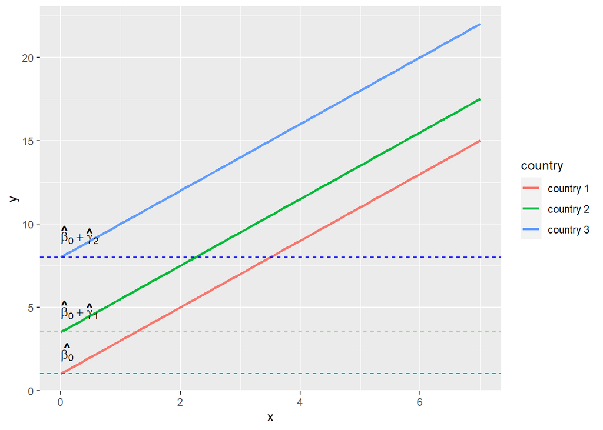

### 2. Схлопываем модель с помощью внутригруппового преобразования

Согласитесь, что такая спецификация модели довольно громоздкая. К примеру, если бы у нас было 30 стран, то 29 параметров (коэффициентов) нам пришлось бы оценивать только для дамми-переменных. Если Вы оцените такую модель, мера $R^2$ “вздуется” из-за такого обилия параметров, но это отнюдь не означает, что модель прекрасна и на ней стоит остановиться. Не будем тащить за собой “хвост” параметров и представим модель в более экономном виде, для этого воспользуемся внутригрупповым преобразованием. Для этого для каждой подгруппы (страна) рассчитаем среднее (как по зависимой переменной, так и по предикторам), а затем заменим исходные переменные на ее отклонение от среднего группового. Посредством такого центрирования избавляемся от константы и шлейфа параметров для дамми.

$$y_{it} - \overline{y_i.} = b_{1}*(x_{it} - \overline{x_i.}) + (e_{it}-\overline{e_i.})$$

## Practice makes perfect

Немного попрактикуемся. Задания к семинару можно найти [здесь](https://politstatistics.github.io/RAPDC_seminar1_2022.pdf).

### Было бы использовано внутригрупповое преобразование?

В данном случае внутригрупповое преобразование не применялось, имеем дело с LSDV-моделью (набор дамми для индивидов)

### Решена ли проблема эндогенности?

Такая модель лишь отчасти решает проблему эндогенности: дамми-переменные поглощают все неизменяющиеся во времени характеристики (к примеру, пол индивида, *будем считать его неизменным во временной перспективе, несмотря на то, что кто-нибудь может нам здесь возразить*). При этом в ошибку уходят оставшиеся изменяющиеся во времени характеристики индивида, потенциально влияющие на заработную плату и связанные с эффективностью труда.